# Customer Segmentation and Purchase Pattern Analysis

Objective Analyze customer behavior through both segmentation (using clustering) and purchase pattern analysis (using association rules) to derive meaningful business insights.

Dataset Requirements

- Download the "Online Retail" dataset from UCI Machine Learning Repository or a similar e-commerce dataset from Kaggle
- Dataset should contain:
  - Customer information for clustering
  - Transaction/purchase information for association rule mining

## Task 1:- Data Preprocessing (2 marks)

- Load and clean the dataset
- Handle missing values and duplicates
- Perform outlier detection and removal
- Feature scaling/normalization
- Create relevant features for both clustering and association analysis

### (a) Load and clean the dataset

```python
# Importing required packages
import numpy as np
import pandas as pd
import warnings as war
war.filterwarnings("ignore")
```

```python
# Defining dataset csv Path
dataSetPath="C:\\Users\\ASUS\\jupyterworkspace\\Assignment & Mini Project\Module_04_Unsupervised Learning and Association Rule Mining\\MiniProject_02\\Online Retail.csv"
# Loading dataSet
dataSetRead=pd.read_csv(dataSetPath)
```

### Inspect structure

```python
# Displaying first 5 records to confirming data loading
print("*****************************************************Displaying below first 5 records**********************************************************")
dataSetRead.head()
```

```
*****************************************************Displaying below first 5 records**********************************************************
```

|  | InvoiceNo | StockCode | Description | Quantity | InvoiceDate | UnitPrice | CustomerID | Country |
| --- | --- | --- | --- | --- | --- | --- | --- | --- |
| 0 | 536365 | 85123A | WHITE HANGING HEART T-LIGHT HOLDER | 6 | 01-12-2010 08:26 | 2.55 | 17850.0 | United Kingdom |
| 1 | 536365 | 71053 | WHITE METAL LANTERN | 6 | 01-12-2010 08:26 | 3.39 | 17850.0 | United Kingdom |
| 2 | 536365 | 84406B | CREAM CUPID HEARTS COAT HANGER | 8 | 01-12-2010 08:26 | 2.75 | 17850.0 | United Kingdom |
| 3 | 536365 | 84029G | KNITTED UNION FLAG HOT WATER BOTTLE | 6 | 01-12-2010 08:26 | 3.39 | 17850.0 | United Kingdom |
| 4 | 536365 | 84029E | RED WOOLLY HOTTIE WHITE HEART. | 6 | 01-12-2010 08:26 | 3.39 | 17850.0 | United Kingdom |

```python
# Displaying last 5 records to confirming data loading
print("*****************************************************Displaying below last 5 records**********************************************************")
dataSetRead.tail()
```

```
*****************************************************Displaying below last 5 records**********************************************************
```

|  | InvoiceNo | StockCode | Description | Quantity | InvoiceDate | UnitPrice | CustomerID | Country |
| --- | --- | --- | --- | --- | --- | --- | --- | --- |
| 541904 | 581587 | 22613 | PACK OF 20 SPACEBOY NAPKINS | 12 | 09-12-2011 12:50 | 0.85 | 12680.0 | France |
| 541905 | 581587 | 22899 | CHILDREN'S APRON DOLLY GIRL | 6 | 09-12-2011 12:50 | 2.10 | 12680.0 | France |
| 541906 | 581587 | 23254 | CHILDRENS CUTLERY DOLLY GIRL | 4 | 09-12-2011 12:50 | 4.15 | 12680.0 | France |
| 541907 | 581587 | 23255 | CHILDRENS CUTLERY CIRCUS PARADE | 4 | 09-12-2011 12:50 | 4.15 | 12680.0 | France |
| 541908 | 581587 | 22138 | BAKING SET 9 PIECE RETROSPOT | 3 | 09-12-2011 12:50 | 4.95 | 12680.0 | France |

```python
# Displaying all records to confirming data loading
print("*****************************************************Displaying below all records**********************************************************")
dataSetRead
```

```
*****************************************************Displaying below all records**********************************************************
```

|  | InvoiceNo | StockCode | Description | Quantity | InvoiceDate | UnitPrice | CustomerID | Country |
| --- | --- | --- | --- | --- | --- | --- | --- | --- |
| 0 | 536365 | 85123A | WHITE HANGING HEART T-LIGHT HOLDER | 6 | 01-12-2010 08:26 | 2.55 | 17850.0 | United Kingdom |
| 1 | 536365 | 71053 | WHITE METAL LANTERN | 6 | 01-12-2010 08:26 | 3.39 | 17850.0 | United Kingdom |
| 2 | 536365 | 84406B | CREAM CUPID HEARTS COAT HANGER | 8 | 01-12-2010 08:26 | 2.75 | 17850.0 | United Kingdom |
| 3 | 536365 | 84029G | KNITTED UNION FLAG HOT WATER BOTTLE | 6 | 01-12-2010 08:26 | 3.39 | 17850.0 | United Kingdom |
| 4 | 536365 | 84029E | RED WOOLLY HOTTIE WHITE HEART. | 6 | 01-12-2010 08:26 | 3.39 | 17850.0 | United Kingdom |
| ... | ... | ... | ... | ... | ... | ... | ... | ... |
| 541904 | 581587 | 22613 | PACK OF 20 SPACEBOY NAPKINS | 12 | 09-12-2011 12:50 | 0.85 | 12680.0 | France |
| 541905 | 581587 | 22899 | CHILDREN'S APRON DOLLY GIRL | 6 | 09-12-2011 12:50 | 2.10 | 12680.0 | France |
| 541906 | 581587 | 23254 | CHILDRENS CUTLERY DOLLY GIRL | 4 | 09-12-2011 12:50 | 4.15 | 12680.0 | France |
| 541907 | 581587 | 23255 | CHILDRENS CUTLERY CIRCUS PARADE | 4 | 09-12-2011 12:50 | 4.15 | 12680.0 | France |
| 541908 | 581587 | 22138 | BAKING SET 9 PIECE RETROSPOT | 3 | 09-12-2011 12:50 | 4.95 | 12680.0 | France |

541909 rows × 8 columns

```python
# Displaying dimension of dataSet
print("Dimention of Dataset:- {}".format(dataSetRead.shape[0:2]))
print("Total number of rows in Dataset:- {}".format(dataSetRead.shape[0]))
print("Total number of columns in Dataset:- {}".format(dataSetRead.shape[1]))
```

```
Dimention of Dataset:- (541909, 8)
Total number of rows in Dataset:- 541909
Total number of columns in Dataset:- 8
```

```python
# Displaying description & statistcal summary of the dataSet
dataSetRead.describe().T
```

|  | count | mean | std | min | 25% | 50% | 75% | max |
| --- | --- | --- | --- | --- | --- | --- | --- | --- |
| Quantity | 541909.0 | 9.552250 | 218.081158 | -80995.00 | 1.00 | 3.00 | 10.00 | 80995.0 |
| UnitPrice | 541909.0 | 4.611114 | 96.759853 | -11062.06 | 1.25 | 2.08 | 4.13 | 38970.0 |
| CustomerID | 406829.0 | 15287.690570 | 1713.600303 | 12346.00 | 13953.00 | 15152.00 | 16791.00 | 18287.0 |

```python
# Displaying description & statistcal summary of the categorical variables
dataSetRead.describe(include='object').T
```

|  | count | unique | top | freq |
| --- | --- | --- | --- | --- |
| InvoiceNo | 541909 | 25900 | 573585 | 1114 |
| StockCode | 541909 | 4070 | 85123A | 2313 |
| Description | 540455 | 4223 | WHITE HANGING HEART T-LIGHT HOLDER | 2369 |
| InvoiceDate | 541909 | 23260 | 31-10-2011 14:41 | 1114 |
| Country | 541909 | 38 | United Kingdom | 495478 |

```python
# Displaying the columns and their respective data types
dataSetRead.info()
```

```
<class 'pandas.core.frame.DataFrame'>
RangeIndex: 541909 entries, 0 to 541908
Data columns (total 8 columns):
 #   Column       Non-Null Count   Dtype
---  ------       --------------   -----
 0   InvoiceNo    541909 non-null  object
 1   StockCode    541909 non-null  object
 2   Description  540455 non-null  object
 3   Quantity     541909 non-null  int64
 4   InvoiceDate  541909 non-null  object
 5   UnitPrice    541909 non-null  float64
 6   CustomerID   406829 non-null  float64
 7   Country      541909 non-null  object
dtypes: float64(2), int64(1), object(5)
memory usage: 33.1+ MB
```

### (b) Handle missing values and duplicates

```python
# Calculating the number of missing values in each column
missingValue_Count=dataSetRead.isnull().sum()
print(missingValue_Count)
```

```
InvoiceNo           0
StockCode           0
Description      1454
Quantity            0
InvoiceDate         0
UnitPrice           0
CustomerID     135080
Country             0
dtype: int64
```

```python
# finding missing values attribues with counts
missingValue_attributes=missingValue_Count[missingValue_Count.where(missingValue_Count.values>0).notnull()]
print(missingValue_attributes)
#Finding the attributes's key which have missing values
print("Below is the list of  missing values attributes:- ")
print(missingValue_attributes.keys())
```

```
Description      1454
CustomerID     135080
dtype: int64
Below is the list of  missing values attributes:-
Index(['Description', 'CustomerID'], dtype='object')
```

```python
# Finding total no. of missing values for dataSet
total_missingvalue_Count=missingValue_Count.sum()
print("total no. of missing values is :- {} ".format(total_missingvalue_Count))
```

```
total no. of missing values is :- 136534
```

```python
# Removing missing data from dataSet
datasetRead = dataSetRead.dropna(subset=['CustomerID','Description'], inplace=True)
```

```python
# Calculating again the number of missing values in each column
missingValue_Count=dataSetRead.isnull().sum()
print(missingValue_Count)
```

```
InvoiceNo      0
StockCode      0
Description    0
Quantity       0
InvoiceDate    0
UnitPrice      0
CustomerID     0
Country        0
dtype: int64
```

```python
# Checking for duplicate records
duplicateValue_Count=dataSetRead.duplicated().sum()
print("Total no of duplicate records count:- {}".format(duplicateValue_Count))
```

```
Total no of duplicate records count:- 5225
```

```python
# Removing duplicates data from dataSet
dataSetRead=dataSetRead.drop_duplicates()
```

```python
# Checking again for duplicate records
duplicateValue_Count=dataSetRead.duplicated().sum()
print("Total no of duplicate records count:- {}".format(duplicateValue_Count))
```

```
Total no of duplicate records count:- 0
```

```python
# Displaying dimension of dataSet
print("Dimention of Dataset:- {}".format(dataSetRead.shape[0:2]))
print("Total number of rows in Dataset:- {}".format(dataSetRead.shape[0]))
print("Total number of columns in Dataset:- {}".format(dataSetRead.shape[1]))
```

```
Dimention of Dataset:- (401604, 8)
Total number of rows in Dataset:- 401604
Total number of columns in Dataset:- 8
```

### (c) Perform outlier detection and removal

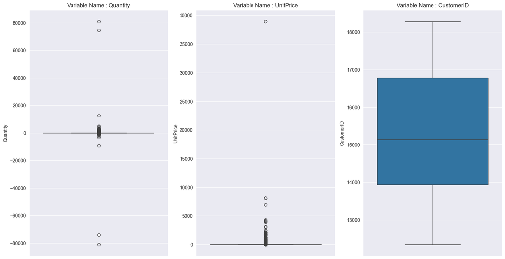

```python
# Importing required package
import seaborn as sbn
import matplotlib.pyplot as plt
# taking list of all numerocal attributes
numerical_attributes = ['Quantity', 'UnitPrice','CustomerID']
dataSetRead_new = dataSetRead[numerical_attributes]
# Set the parameters that control the general style of the plots.
sbn.set_style("darkgrid")
# Selecting all numerical attributes columns names
cols = dataSetRead_new.columns
#Plotting Box plot for each numerical attributes
plt.figure(figsize=(15, 30) )
for count, item in enumerate(cols, 1):
    plt.subplot(4, 3, count)
    sbn.boxplot(dataSetRead_new[item])
    plt.title(f"Variable Name : {item}")

plt.tight_layout()
plt.show()
```

```python
# Calculating IQR for Quantity and UnitPrice
Q1 = dataSetRead[['Quantity', 'UnitPrice','CustomerID']].quantile(0.25)
Q3 = dataSetRead[['Quantity', 'UnitPrice','CustomerID']].quantile(0.75)
IQR = Q3 - Q1

# Identify outliers for each attribute
outliers_quantity = ((dataSetRead['Quantity'] < (Q1['Quantity'] - 1.5 * IQR['Quantity'])) |
                     (dataSetRead['Quantity'] > (Q3['Quantity'] + 1.5 * IQR['Quantity']))).sum()

outliers_unitprice = ((dataSetRead['UnitPrice'] < (Q1['UnitPrice'] - 1.5 * IQR['UnitPrice'])) |
                      (dataSetRead['UnitPrice'] > (Q3['UnitPrice'] + 1.5 * IQR['UnitPrice']))).sum()

outliers_CustomerID = ((dataSetRead['CustomerID'] < (Q1['CustomerID'] - 1.5 * IQR['CustomerID'])) |
                      (dataSetRead['CustomerID'] > (Q3['CustomerID'] + 1.5 * IQR['CustomerID']))).sum()

# Displaying results for each attribute
print(f"Total outliers in 'Quantity': {outliers_quantity}")
print(f"Total outliers in 'UnitPrice': {outliers_unitprice}")
print(f"Total outliers in 'CustomerID': {outliers_CustomerID}")
```

```
Total outliers in 'Quantity': 26646
Total outliers in 'UnitPrice': 35802
Total outliers in 'CustomerID': 0
```

#### Observation:- From the above box plots it shows that there is no outliers in the CustomerID attribute

```python
# Removing outliers from dataSet
# Identify outliers
outlier_mask = (dataSetRead[['Quantity', 'UnitPrice','CustomerID']] < (Q1 - 1.5 * IQR)) | \
               (dataSetRead[['Quantity', 'UnitPrice','CustomerID']] > (Q3 + 1.5 * IQR))

# Remove outliers
dataSetRead = dataSetRead[~outlier_mask.any(axis=1)]
```

```python
# Displaying dimension of dataSet
print("Dimention of Dataset:- {}".format(dataSetRead.shape[0:2]))
print("Total number of rows in Dataset:- {}".format(dataSetRead.shape[0]))
print("Total number of columns in Dataset:- {}".format(dataSetRead.shape[1]))
```

```
Dimention of Dataset:- (339453, 8)
Total number of rows in Dataset:- 339453
Total number of columns in Dataset:- 8
```

### (d) Feature scaling/normalization

```python
# Importing required packages
from sklearn.preprocessing import MinMaxScaler
scaler = MinMaxScaler()
dataSetRead[['Quantity', 'UnitPrice']] = scaler.fit_transform(dataSetRead[['Quantity', 'UnitPrice']])
```

```python
# Displaying all records
print("*****************************************************Displaying below all records**********************************************************")
dataSetRead
```

```
*****************************************************Displaying below all records**********************************************************
```

|  | InvoiceNo | StockCode | Description | Quantity | InvoiceDate | UnitPrice | CustomerID | Country |
| --- | --- | --- | --- | --- | --- | --- | --- | --- |
| 0 | 536365 | 85123A | WHITE HANGING HEART T-LIGHT HOLDER | 0.475 | 01-12-2010 08:26 | 0.340000 | 17850.0 | United Kingdom |
| 1 | 536365 | 71053 | WHITE METAL LANTERN | 0.475 | 01-12-2010 08:26 | 0.452000 | 17850.0 | United Kingdom |
| 2 | 536365 | 84406B | CREAM CUPID HEARTS COAT HANGER | 0.525 | 01-12-2010 08:26 | 0.366667 | 17850.0 | United Kingdom |
| 3 | 536365 | 84029G | KNITTED UNION FLAG HOT WATER BOTTLE | 0.475 | 01-12-2010 08:26 | 0.452000 | 17850.0 | United Kingdom |
| 4 | 536365 | 84029E | RED WOOLLY HOTTIE WHITE HEART. | 0.475 | 01-12-2010 08:26 | 0.452000 | 17850.0 | United Kingdom |
| ... | ... | ... | ... | ... | ... | ... | ... | ... |
| 541904 | 581587 | 22613 | PACK OF 20 SPACEBOY NAPKINS | 0.625 | 09-12-2011 12:50 | 0.113333 | 12680.0 | France |
| 541905 | 581587 | 22899 | CHILDREN'S APRON DOLLY GIRL | 0.475 | 09-12-2011 12:50 | 0.280000 | 12680.0 | France |
| 541906 | 581587 | 23254 | CHILDRENS CUTLERY DOLLY GIRL | 0.425 | 09-12-2011 12:50 | 0.553333 | 12680.0 | France |
| 541907 | 581587 | 23255 | CHILDRENS CUTLERY CIRCUS PARADE | 0.425 | 09-12-2011 12:50 | 0.553333 | 12680.0 | France |
| 541908 | 581587 | 22138 | BAKING SET 9 PIECE RETROSPOT | 0.400 | 09-12-2011 12:50 | 0.660000 | 12680.0 | France |

339453 rows × 8 columns

### (e) Create relevant features for both clustering and association analysis

#### * For Clustering:

RFM features:

--> Recency: Days since last purchase.

--> Frequency: Number of transactions per customer.

```python
# Importing required packages
from datetime import datetime
from datetime import timedelta
```

```python
# Creating Recency, Frequency, Monetary features
dataSetRead['InvoiceDate'] = pd.to_datetime(dataSetRead['InvoiceDate'],format="%d-%m-%Y %H:%M")
snapshot_date = max(dataSetRead['InvoiceDate']) + timedelta(days=1)
rfm = dataSetRead.groupby('CustomerID').agg({
    'InvoiceDate': lambda x: (snapshot_date - x.max()).days,
    'InvoiceNo': 'count',
    'UnitPrice': 'sum'
}).rename(columns={
    'InvoiceDate': 'Recency',
    'InvoiceNo': 'Frequency',
    'UnitPrice': 'Monetary'
})
```

#### * For Association Rule Mining:

Create a basket format:

```
   --> Group data by InvoiceNo and pivot StockCode or Description into a binary matrix (0/1).

   --> Use this format for market basket analysis.
```

```python
# Basket format
basket = dataSetRead.groupby(['InvoiceNo', 'Description'])['Quantity'].sum().unstack().fillna(0)
basket = basket.applymap(lambda x: 1 if x > 0 else 0)
```

## Task 2:- Customer Segmentation using Clustering (5 marks)

- Apply Elbow method to determine optimal number of clusters (1 mark)
- Implement three clustering algorithms:
  - K-means clustering (1.5 marks)
  - Hierarchical clustering (1.5 marks)
  - DBSCAN (1 mark)
- Calculate and compare Silhouette coefficients for each method

### (a) Apply Elbow method to determine optimal number of clusters

The Elbow method helps determine the optimal number of clusters ( 𝑘 k) for clustering algorithms like K-Means by evaluating the Within-Cluster-Sum-of-Squares (WCSS) for different 𝑘 k values.

Steps:

1- Compute K-Means for a range of k values (e.g., 1 to 10).

2- Plot k vs WCSS.

3- Look for the "elbow point" where adding clusters doesn't reduce WCSS significantly.

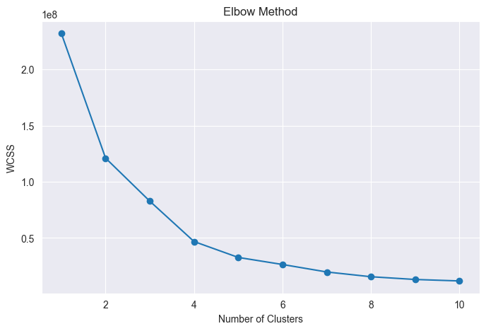

```python
# Importing required package
from sklearn.cluster import KMeans
wcss = []
for k in range(1, 11):
    kmeans = KMeans(n_clusters=k, random_state=42)
    kmeans.fit(rfm)
    wcss.append(kmeans.inertia_)

# Plotting the Elbow graph
plt.figure(figsize=(8, 5))
plt.plot(range(1, 11), wcss, marker='o')
plt.title('Elbow Method')
plt.xlabel('Number of Clusters')
plt.ylabel('WCSS')
plt.show()
```

From the Elbow method above graph , the optimal number of clusters 𝑘 k can typically be identified at the "elbow" point of the curve, where the rate of decrease in the Within-Cluster Sum of Squares (WCSS) starts to slow down.

### (b) Implement three clustering algorithms:

#### (b.1) K-Means Clustering

--> Use the optimal 𝑘 identified from the Elbow method.

--> Apply the KMeans algorithm.

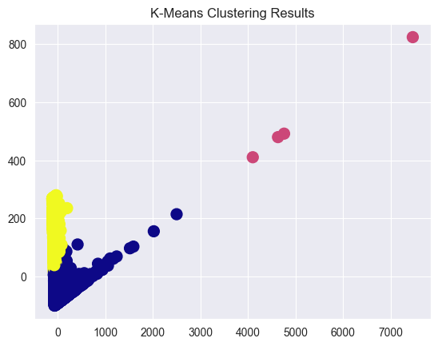

```python
# K-Means clustering
kmeans = KMeans(n_clusters=3, random_state=42)
#rfm['KMeans_Cluster'] = kmeans.fit_predict(rfm)
kmeans_labels = kmeans.fit_predict(rfm)
kmeans_silhouette = silhouette_score(rfm, kmeans_labels)
# Visualize clusters (optional, using 2D or 3D PCA)
from sklearn.decomposition import PCA
pca = PCA(n_components=2)
rfm_pca = pca.fit_transform(rfm)
plt.scatter(rfm_pca[:, 0], rfm_pca[:, 1], c=kmeans_labels, cmap="plasma", s=100)
plt.title('K-Means Clustering Results')
plt.show()
```

#### (b.2) Hierarchical Clustering

--> Use Agglomerative Clustering.

--> Visualize the dendrogram to validate clusters.

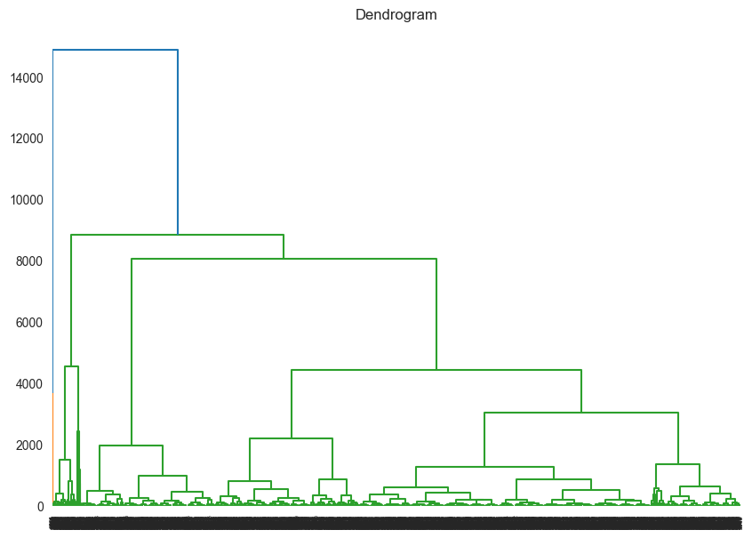

```python
# Importing required packages
from scipy.cluster.hierarchy import dendrogram, linkage
from sklearn.cluster import AgglomerativeClustering
# Dendrogram
linked = linkage(rfm, method='ward')
plt.figure(figsize=(10, 7))
dendrogram(linked)
plt.title('Dendrogram')
plt.show()
```

```python
# Apply Agglomerative Clustering
hierarchical_clustering = AgglomerativeClustering(n_clusters=3, metric='euclidean', linkage='ward')
rfm['Hierarchical_Cluster'] = hierarchical_clustering.fit_predict(rfm[['Recency', 'Frequency', 'Monetary']])
```

#### (b.3) DBSCAN (Density-Based Spatial Clustering of Applications with Noise)

--> DBSCAN identifies clusters based on density rather than predetermined 𝑘

--> Use eps (radius) and min_samples (min points per cluster) to define density.

```python
from sklearn.cluster import DBSCAN

# Apply DBSCAN
dbscan = DBSCAN(eps=0.5, min_samples=3)
rfm['DBSCAN_Cluster'] = dbscan.fit_predict(rfm[['Recency', 'Frequency', 'Monetary']])
```

### (c) Calculate and compare Silhouette coefficients for each method

The Silhouette coefficient measures how similar each point is to its own cluster compared to other clusters. A high silhouette score indicates good clustering.

```python
# Importing required package
from sklearn.metrics import silhouette_score

# Silhouette scores
kmeans_silhouette = silhouette_score(rfm[['Recency', 'Frequency', 'Monetary']], kmeans_labels)
hierarchical_silhouette = silhouette_score(rfm[['Recency', 'Frequency', 'Monetary']], rfm['Hierarchical_Cluster'])
dbscan_silhouette = silhouette_score(rfm[['Recency', 'Frequency', 'Monetary']], rfm['DBSCAN_Cluster'])

# Print results
print(f"K-Means Silhouette Score: {kmeans_silhouette}")
print(f"Hierarchical Clustering Silhouette Score: {hierarchical_silhouette}")
print(f"DBSCAN Silhouette Score: {dbscan_silhouette}")
```

```
K-Means Silhouette Score: 0.4998255169836387
Hierarchical Clustering Silhouette Score: 0.6959473543829896
DBSCAN Silhouette Score: -0.5909900158153845
```

#### Interpretation of Scores

K-Means Clustering:

Silhouette Score: 0.4998

This indicates that the clustering is moderately well-formed, with a decent separation between clusters but some degree of overlap or points near

cluster boundaries.

Hierarchical Clustering:

Silhouette Score: 0.6959

This is a high score, suggesting that the clusters are well-separated, compact, and appropriately represent the underlying structure of the data.

It outperforms K-Means in this case.

DBSCAN:

Silhouette Score: -0.5909

A negative score indicates that the clustering is poor, with many points assigned to incorrect clusters or classified as noise. This is likely due

to the dataset not being well-suited to DBSCAN or suboptimal tuning of its eps and min_samples parameters.

### Task 3:-Purchase Pattern Analysis using Association Rules (5 marks)

- Prepare transaction data for association rule mining
- Define support and confidence thresholds
- Apply Apriori algorithm to discover frequent itemsets
- Generate and analyze association rules
- Compare rules based on different metrics (support, confidence, lift)
- Provide business insights from discovered rules

#### (a) Prepare transaction data for association rule mining

Association rule mining requires transactional data in the format of InvoiceID and associated Items.

Steps: --> Transform the Dataset:

```
Group data by InvoiceNo and aggregate items into lists.

Exclude invalid transactions, such as cancellations (InvoiceNo starting with "C") and outliers.
```

--> Create a Transaction-Item Matrix:

```
Use one-hot encoding to transform item transactions into a binary matrix.
```

```python
# Filter valid transactions
transactions = dataSetRead[dataSetRead['Quantity'] > 0]
transactions = transactions[~transactions['InvoiceNo'].str.contains('C', na=False)]

# Group by InvoiceNo and aggregate items
transaction_data = transactions.groupby('InvoiceNo')['Description'].apply(list)

# Convert to a transactional matrix for one-hot encoding

from mlxtend.preprocessing import TransactionEncoder

te = TransactionEncoder()
transaction_matrix = te.fit_transform(transaction_data)
df_transactions = pd.DataFrame(transaction_matrix, columns=te.columns_)
```

#### (b) Define support and confidence thresholds

Support: Minimum proportion of transactions containing an itemset.

Confidence: Conditional probability of consequent given antecedent.

Example:

Set support = 0.01 (1% of all transactions).

Set confidence = 0.2 (20% likelihood).

#### (c) Apply Apriori algorithm to discover frequent itemsets

The Apriori algorithm identifies frequent itemsets based on the minimum support threshold.

```python
from mlxtend.frequent_patterns import apriori

# Generate frequent itemsets
frequent_itemsets = apriori(df_transactions, min_support=0.01, use_colnames=True)

# Add the length of itemsets for analysis
frequent_itemsets['length'] = frequent_itemsets['itemsets'].apply(len)

print(frequent_itemsets)
```

```
      support                                           itemsets  length
0    0.010811                 ( SET 2 TEA TOWELS I LOVE LONDON )       1
1    0.012652                           (10 COLOUR SPACEBOY PEN)       1
2    0.010573                  (12 MESSAGE CARDS WITH ENVELOPES)       1
3    0.015800                    (12 PENCIL SMALL TUBE WOODLAND)       1
4    0.016810              (12 PENCILS SMALL TUBE RED RETROSPOT)       1
..        ...                                                ...     ...
929  0.014137  (LUNCH BAG RED RETROSPOT, LUNCH BAG WOODLAND, ...       3
930  0.012058  (LUNCH BAG RED RETROSPOT, LUNCH BAG SUKI DESIG...       3
931  0.010039  (LUNCH BAG SUKI DESIGN , LUNCH BAG WOODLAND, L...       3
932  0.010692  (POPPY'S PLAYHOUSE LIVINGROOM , POPPY'S PLAYHO...       3
933  0.010395  (LUNCH BAG RED RETROSPOT, LUNCH BAG PINK POLKA...       4

[934 rows x 3 columns]
```

#### (d) Generate and analyze association rules

Use the frequent itemsets to generate association rules with metrics like support, confidence, and lift.

```python
from mlxtend.frequent_patterns import association_rules

# Generate rules
rules = association_rules(frequent_itemsets,metric="confidence", min_threshold=0.2,num_itemsets=len(transaction_data))

# Add additional metrics for ranking
rules['lift'] = rules['lift']
rules = rules.sort_values(by='lift', ascending=False)

print(rules.head())
```

```
                antecedents             consequents  antecedent support  \
147     (HERB MARKER THYME)  (HERB MARKER ROSEMARY)            0.010811
146  (HERB MARKER ROSEMARY)     (HERB MARKER THYME)            0.011108
144  (HERB MARKER ROSEMARY)   (HERB MARKER PARSLEY)            0.011108
145   (HERB MARKER PARSLEY)  (HERB MARKER ROSEMARY)            0.010930
140  (HERB MARKER ROSEMARY)     (HERB MARKER BASIL)            0.011108

     consequent support   support  confidence       lift  representativity  \
147            0.011108  0.010217    0.945055  85.080214               1.0
146            0.010811  0.010217    0.919786  85.080214               1.0
144            0.010930  0.010157    0.914439  83.666153               1.0
145            0.011108  0.010157    0.929348  83.666153               1.0
140            0.010930  0.010039    0.903743  82.687602               1.0

     leverage  conviction  zhangs_metric   jaccard  certainty  kulczynski
147  0.010097   17.997838       0.999047  0.873096   0.944438    0.932421
146  0.010097   12.331892       0.999347  0.873096   0.918909    0.932421
144  0.010036   11.559760       0.999146  0.855000   0.913493    0.921893
145  0.010036   13.996628       0.998966  0.855000   0.928554    0.921893
140  0.009917   10.275342       0.999003  0.836634   0.902680    0.911111
```

#### Metrics for Rule Evaluation:

1- Support: Measures how frequently the itemset occurs.

2- Confidence: Measures the likelihood of seeing the consequent given the antecedent.

3- Lift: Measures the strength of the rule compared to random chance (lift > 1 indicates a strong rule).

#### (d) Compare rules based on different metrics (support, confidence, lift)

```python
# Sorting rules by support in descending order
rules_sorted_by_support = rules.sort_values('support', ascending=False)
print("Rules Sorted by Support:")
print(rules_sorted_by_support[['antecedents', 'consequents', 'support']].head())
```

```
Rules Sorted by Support:
                            antecedents                         consequents  \
110  (ROSES REGENCY TEACUP AND SAUCER )   (GREEN REGENCY TEACUP AND SAUCER)
111   (GREEN REGENCY TEACUP AND SAUCER)  (ROSES REGENCY TEACUP AND SAUCER )
25          (ALARM CLOCK BAKELIKE RED )        (ALARM CLOCK BAKELIKE GREEN)
26         (ALARM CLOCK BAKELIKE GREEN)         (ALARM CLOCK BAKELIKE RED )
373           (LUNCH BAG RED RETROSPOT)           (LUNCH BAG PINK POLKADOT)

      support
110  0.030710
111  0.030710
25   0.030591
26   0.030591
373  0.028631
```

```python
# Sorting rules by confidence in descending order
rules_sorted_by_confidence = rules.sort_values('confidence', ascending=False)
print("Rules Sorted by Confidence:")
print(rules_sorted_by_confidence[['antecedents', 'consequents', 'confidence']].head())
```

```
Rules Sorted by Confidence:
                antecedents             consequents  confidence
147     (HERB MARKER THYME)  (HERB MARKER ROSEMARY)    0.945055
145   (HERB MARKER PARSLEY)  (HERB MARKER ROSEMARY)    0.929348
146  (HERB MARKER ROSEMARY)     (HERB MARKER THYME)    0.919786
141     (HERB MARKER BASIL)  (HERB MARKER ROSEMARY)    0.918478
144  (HERB MARKER ROSEMARY)   (HERB MARKER PARSLEY)    0.914439
```

```python
# Sorting rules by lift in descending order
rules_sorted_by_lift = rules.sort_values('lift', ascending=False)
print("Rules Sorted by Lift:")
print(rules_sorted_by_lift[['antecedents', 'consequents', 'lift']].head())
```

```
Rules Sorted by Lift:
                antecedents             consequents       lift
147     (HERB MARKER THYME)  (HERB MARKER ROSEMARY)  85.080214
146  (HERB MARKER ROSEMARY)     (HERB MARKER THYME)  85.080214
144  (HERB MARKER ROSEMARY)   (HERB MARKER PARSLEY)  83.666153
145   (HERB MARKER PARSLEY)  (HERB MARKER ROSEMARY)  83.666153
140  (HERB MARKER ROSEMARY)     (HERB MARKER BASIL)  82.687602
```

#### Comparison of Rules Based on Metrics

Support

Definition: Proportion of transactions containing both antecedent and consequent.

Top Rule:

```
   --> Antecedent: (ROSES REGENCY TEACUP AND SAUCER)

   --> Consequent: (GREEN REGENCY TEACUP AND SAUCER)

   --> Support: 0.030710 (Appears in 3.07% of transactions).
```

Insights:

```
  --> These are frequent combinations, suitable for promotions targeting large customer segments.

  -->  Useful for bulk purchasing or display optimization.
```

Confidence

Definition: Likelihood of consequent being purchased given the antecedent.

Top Rule:

```
  --> Antecedent: (HERB MARKER THYME)
  --> Consequent: (HERB MARKER ROSEMARY)
  --> Confidence: 0.945055 (94.5% of transactions with THYME also include ROSEMARY).
```

Insights:

```
   --> High confidence indicates strong predictability.

   --> Use for targeted recommendations, e.g., recommending ROSEMARY if THYME is in a customer's cart.
   .
```

Lift

Definition: Strength of the association compared to random co-occurrence.

Top Rule:

```
    --> Antecedent: (HERB MARKER THYME)

    --> Consequent: (HERB MARKER ROSEMARY)

    --> Lift: 85.08 (Occurs 85 times more than expected by chance).
```

Insights:

```
    --> High lift suggests a meaningful, non-random relationship.

    --> Useful for strategic bundling or cross-selling of products.-
```

### (e) Provide business insights from discovered rules

### Based on the discovered rules:

1- Cross-Selling Opportunities:

2- Inventory Management:

--> High-lift rules highlight products with strong associations, helping optimize stock placement.

3- Promotional Strategies:

4- Personalized Recommendations:

--> Use the rules to recommend related products in e-commerce platforms.